# VLM Wrong Predictions: bridge_type

Actual: Beam

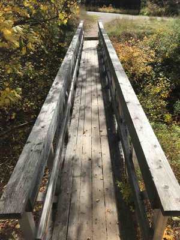

25207__AST_IM_20211002_121352.jpeg

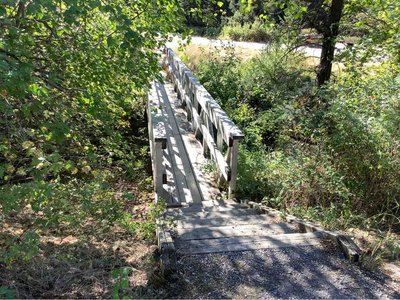

62914__AST_EX_20220910_110610.jpeg

Asset 103256 1 image

Predicted: Beam (conf: N/A)

Actual: Truss

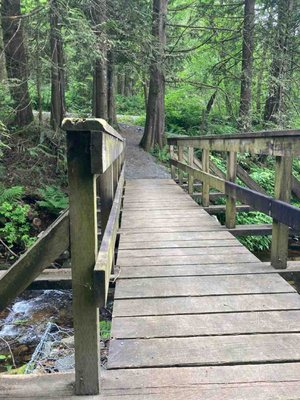

48053__AST_IM_20220620_140345.jpeg

Asset 107973 3 images

Predicted: Truss (conf: N/A)

Actual: Beam

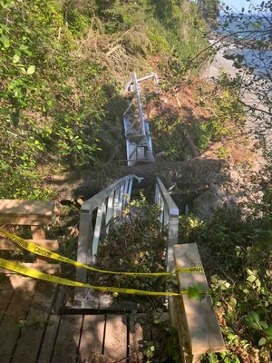

55092__AST_IM_20220720_163218.jpeg

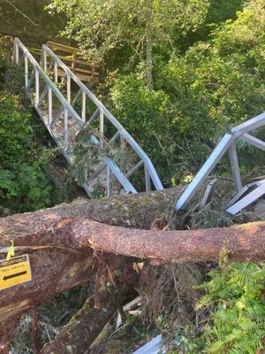

55093__AST_IM_20220720_162852.jpeg

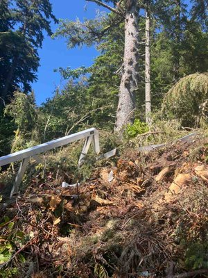

55113__AST_IM_20220720_162859.jpeg

Asset 109138 2 images

Predicted: Truss (conf: N/A)

Actual: Beam

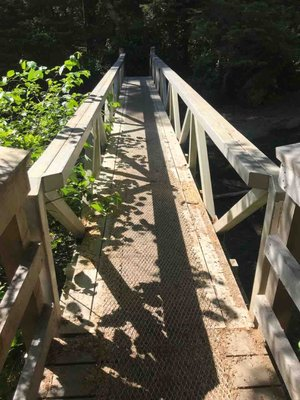

56715__AST_IM_20220720_162002.jpeg

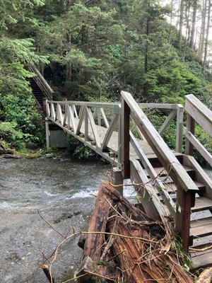

76405__AST_EX_20241025_101407.jpeg

Asset 112834 4 images

Predicted: Beam (conf: N/A)

Actual: Truss

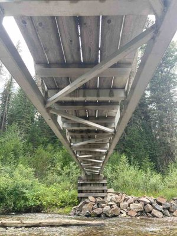

61096__AST_IM_20220824_144028.jpeg

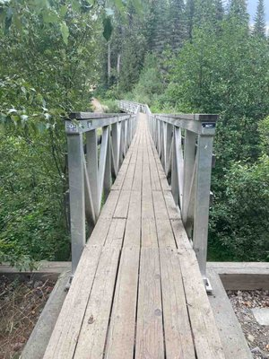

61106__AST_IM_20220824_144336.jpeg

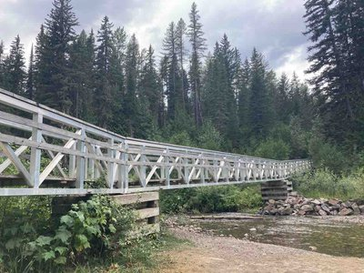

61107__AST_IM_20220824_144013.jpeg

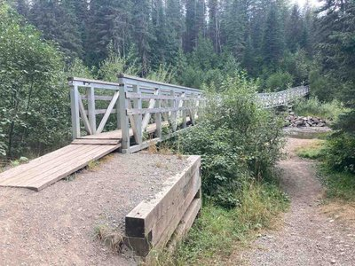

61118__AST_IM_20220824_143953.jpeg

Asset 116737 1 image

Predicted: Truss (conf: N/A)

Actual: Beam

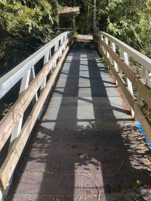

64694__AST_IM_20230302_104806.jpeg

Asset 123310 1 image

Predicted: Beam (conf: N/A)

Actual: Fallen Tree

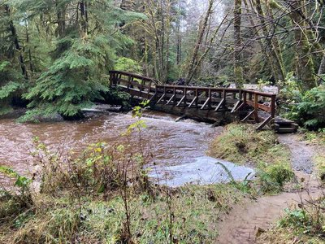

77432__AST_IM_20241113_143720.jpeg

Asset 126199 1 image

Predicted: Beam (conf: N/A)

Actual: Truss

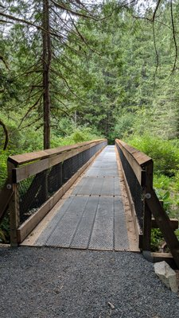

83496__bridge_inland_lake.jpg

Asset 127136 2 images

Predicted: Beam (conf: N/A)

Actual: Other

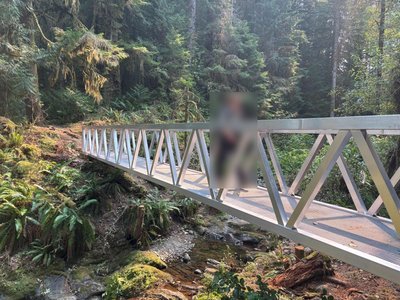

90541__Footpath_bridge_1.jpg

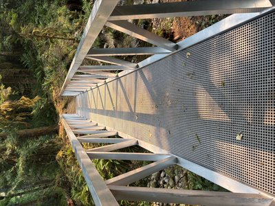

90542__Footpath_bridge_2.jpg

Asset 128878 3 images

Predicted: Beam (conf: N/A)

Actual: Truss

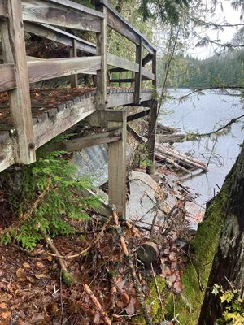

91010__AST_IM_20251122_103839.jpeg

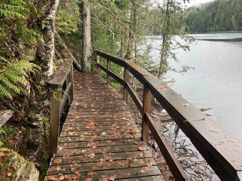

91011__AST_IM_20251122_103816.jpeg

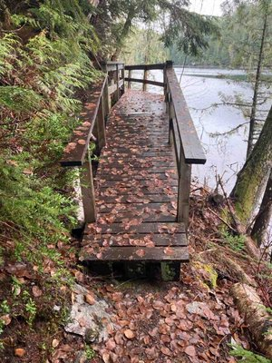

91012__AST_IM_20251122_103756.jpeg

Asset 53985 2 images

Predicted: Truss (conf: N/A)

Actual: Beam

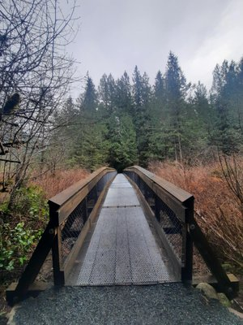

84285__Inland_pedestrian_bridge_DFAA_1.png

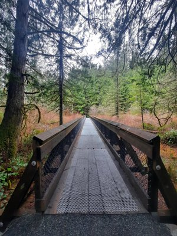

84286__Inland_pedestrian_bridge_DFAA_2.png

Asset 63066 2 images

Predicted: Truss (conf: N/A)

Actual: Beam

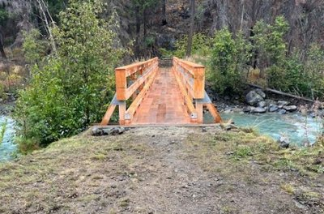

89014__image.png

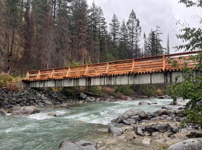

89015__image.png

Asset 63540 10 images

Predicted: Beam (conf: N/A)

Actual: Suspension

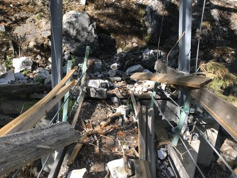

47649__IMG_0223.jpg

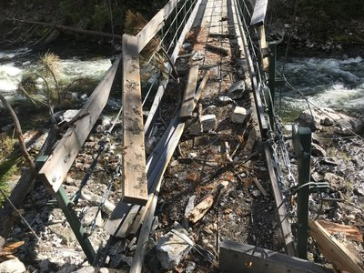

47650__IMG_0224.jpg

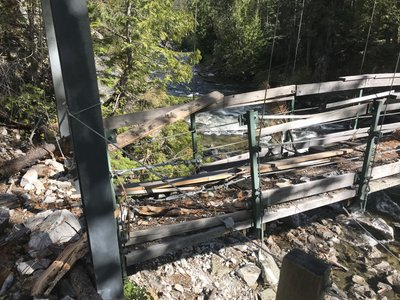

47651__IMG_0225.jpg

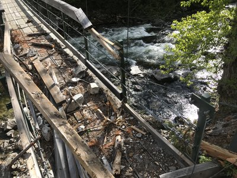

47652__IMG_0230.jpg

[figure not shown]

47653__IMG_0231.jpg

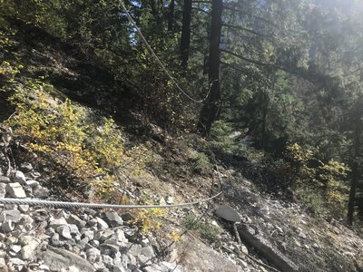

47666__IMG_8090.JPG

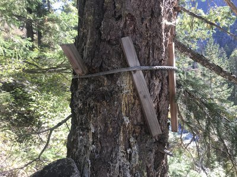

47667__IMG_8100.JPG

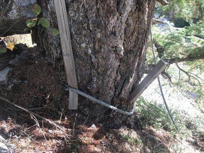

47668__IMG_8102.JPG

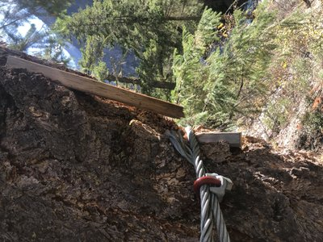

47669__IMG_8110.JPG

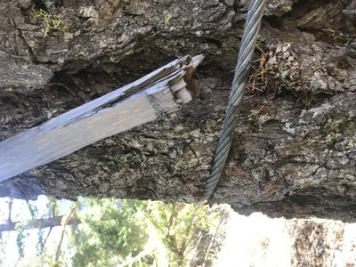

47670__IMG_8111.JPG

Asset 65497 2 images

Predicted: Beam (conf: N/A)

Actual: Truss

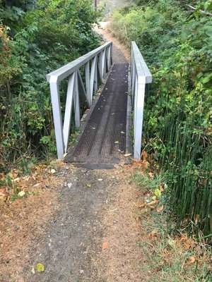

20022__AST_EX_20210904_141825.jpeg

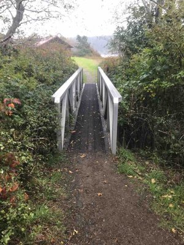

26366__AST_EX_20211012_113507.jpeg

Asset 86525 1 image

Predicted: Beam (conf: N/A)

Actual: Truss

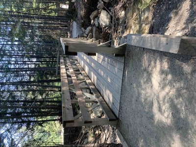

13953__AST_IM_20210812_112957.jpeg

Asset 94144 1 image

Predicted: Beam (conf: N/A)

Actual: Truss

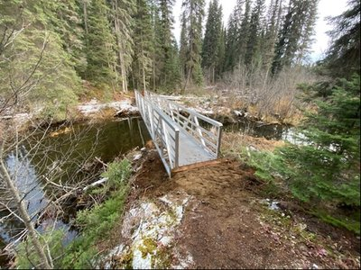

32678__Babcock_Bridge___2.jpg

Asset 102354 1 image

Predicted: Other (conf: N/A)

Actual: Beam

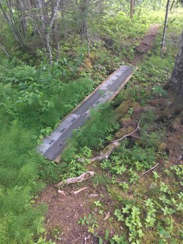

46492__AST_IM_20220615_114011.jpeg

Asset 104172 1 image

Predicted: Truss (conf: N/A)

Actual: Beam

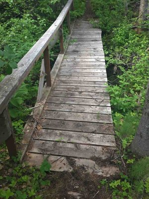

48581__AST_IM_20220622_173502.jpeg

Asset 109151 2 images

Predicted: Truss (conf: N/A)

Actual: Beam

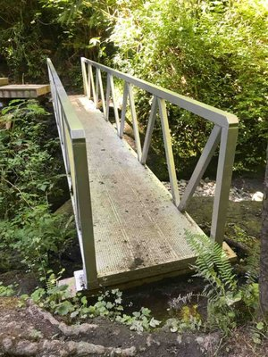

56720__AST_IM_20220720_154121.jpeg

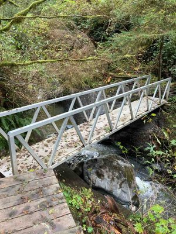

76412__AST_EX_20241025_111027.jpeg

Asset 111951 2 images

Predicted: Fallen Tree (conf: N/A)

Actual: Beam

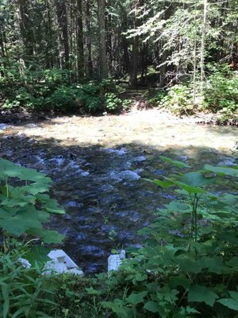

59924__AST_IM_20220729_122412.jpeg

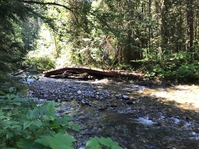

59925__AST_IM_20220729_122405.jpeg

Asset 126721 4 images

Predicted: Beam (conf: N/A)

Actual: Truss

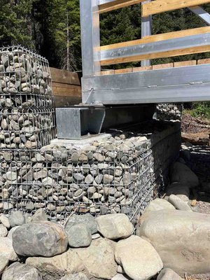

85400__AST_IM_20250716_120422.jpeg

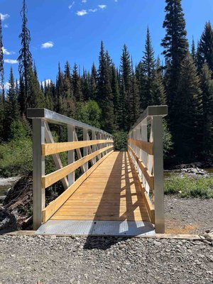

85403__AST_IM_20250716_120324.jpeg

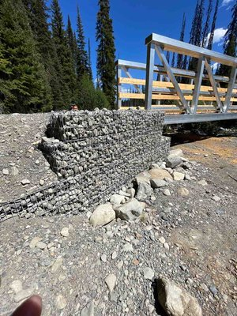

85406__AST_IM_20250716_120341.jpeg

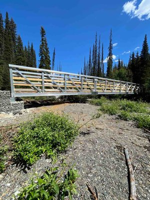

85407__AST_IM_20250716_120405.jpeg

Asset 126774 1 image

Predicted: Beam (conf: N/A)

Actual: Truss

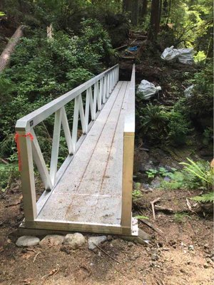

85613__AST_IM_20250730_124302.jpeg

Asset 126915 3 images

Predicted: Truss (conf: N/A)

Actual: Beam

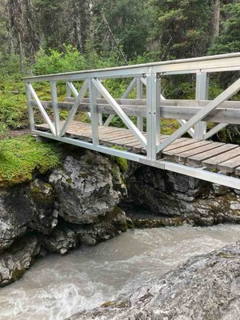

85843__AST_IM_20250730_161027.jpeg

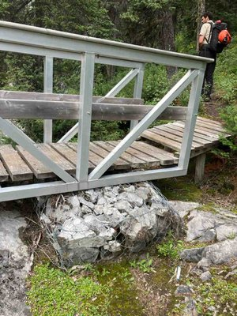

85844__AST_IM_20250730_161039.jpeg

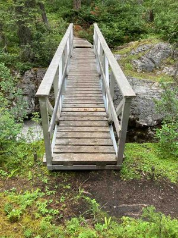

85845__AST_IM_20250730_160958.jpeg

Asset 127145 1 image

Predicted: Other (conf: N/A)

Actual: Beam

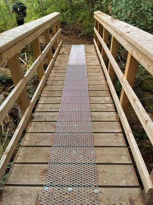

87017__AST_IM_20250819_135439.jpeg

Asset 128273 3 images